# Machine Learning Models

## University

University of Tehran

## Student Info

Name : Amirhossein  
Last Name : Arefzadeh  
SID : 810101604

## Project Overview

This project develops a machine learning model to predict hotel prices using a structured approach. It begins with data preparation, including exploratory data analysis, visualization, and feature engineering to uncover patterns and optimize data for modeling. Next, models like Naive Bayes, Decision Trees, Random Forests, and XGBoost are trained and fine-tuned through techniques such as normalization and hyperparameter optimization. Finally, the models are evaluated using metrics like accuracy, precision, and F1-score, with results documented in a Jupyter Notebook for clarity and reproducibility.

## 📚 Import Required Libraries

In this section, we import the necessary libraries to enable the required functionalities and operations for the project.

```python
import numpy as np
import pandas as pd
import seaborn as sns
import xgboost as xgb
import missingno as msno
import matplotlib.pyplot as plt
from sklearn.model_selection import train_test_split, GridSearchCV, RandomizedSearchCV
from sklearn.preprocessing import MinMaxScaler, StandardScaler
from sklearn.naive_bayes import GaussianNB
from sklearn.metrics import confusion_matrix, precision_score, recall_score, f1_score, accuracy_score
from sklearn.tree import DecisionTreeClassifier, plot_tree
from sklearn.ensemble import RandomForestClassifier, AdaBoostClassifier
from sklearn.base import BaseEstimator, ClassifierMixin, clone
```

## 🧹 Data Preprocessing

In this section, we perform data preprocessing to clean, transform, and prepare the dataset for analysis or modeling.

### 📥 Load Dataset

In this subsection, we load the dataset as a pandas dataframe 🐼

```python
hotels_df = pd.read_csv('hotels_in_europe.csv')
```

### 🔎 Data Overview

In this subsection, we provide an overview of the dataset, including its structure, features, and key characteristics to understand the data before analysis or modeling.

```python
hotels_df.head()
```

|  | name | location | price | rating | quality | review | bed | size | distance_from_center | room_type | nights | adults | free_cancellation |
| --- | --- | --- | --- | --- | --- | --- | --- | --- | --- | --- | --- | --- | --- |
| 0 | WIT Hotel | 9th arr., Paris | IRR 7,951,542 | 7.1 | Good | 3,300 reviews | 1 double bed | 20m² | 1.9 | Suite | 1 night | 1 adult | NaN |
| 1 | UCPA SPORT STATION HOSTEL PARIS | 19th arr., Paris | IRR 1,397,677 | 8.0 | Very good | 5,921 reviews | 1 single bed | NaN | 4.6 | Single Bed in 6-Bed Dormitory Room | 1 night | 1 adult | NaN |
| 2 | Timhotel Montmartre | 18th arr., Paris | IRR 7,569,083 | 8.3 | Very good | 2,532 reviews | 1 single bed | NaN | 3.4 | Comfort Single Room | 1 night | 1 adult | NaN |
| 3 | Hôtel Galileo Champs Elysées | 8th arr., Paris | IRR 6,447,737 | 8.6 | Fabulous | 1,457 reviews | 1 large double bed | NaN | 4.2 | Classic Room | 1 night | 1 adult | NaN |
| 4 | Hôtel Le Daum | 12th arr., Paris | IRR 7,913,496 | 8.3 | Very good | 1,273 reviews | 1 double bed | NaN | 4.1 | Comfort Double Room | 1 night | 1 adult | NaN |

```python
display(hotels_df.info())
```

```
<class 'pandas.core.frame.DataFrame'>
RangeIndex: 7322 entries, 0 to 7321
Data columns (total 13 columns):
 #   Column                Non-Null Count  Dtype
---  ------                --------------  -----
 0   name                  7322 non-null   object
 1   location              7322 non-null   object
 2   price                 7322 non-null   object
 3   rating                7129 non-null   float64
 4   quality               7169 non-null   object
 5   review                7169 non-null   object
 6   bed                   7299 non-null   object
 7   size                  2454 non-null   object
 8   distance_from_center  7322 non-null   float64
 9   room_type             7322 non-null   object
 10  nights                7322 non-null   object
 11  adults                7322 non-null   object
 12  free_cancellation     583 non-null    object
dtypes: float64(2), object(11)
memory usage: 743.8+ KB
```

```
None
```

```python
hotels_df.describe()
```

|  | rating | distance_from_center |
| --- | --- | --- |
| count | 7129.000000 | 7322.000000 |
| mean | 7.742783 | 24.699399 |
| std | 1.128965 | 82.440210 |
| min | 1.000000 | 0.500000 |
| 25% | 7.300000 | 2.200000 |
| 50% | 8.000000 | 3.700000 |
| 75% | 8.400000 | 5.800000 |
| max | 10.000000 | 500.000000 |

```python
print(hotels_df.select_dtypes(include=['number']).columns)
print(hotels_df.select_dtypes(include=['object']).columns)
```

```
Index(['rating', 'distance_from_center'], dtype='object')
Index(['name', 'location', 'price', 'quality', 'review', 'bed', 'size',
       'room_type', 'nights', 'adults', 'free_cancellation'],
      dtype='object')
```

### 🥇 Unique Values

In this subsection, we examine the unique values in the dataset's features to understand the diversity and distribution of the data.

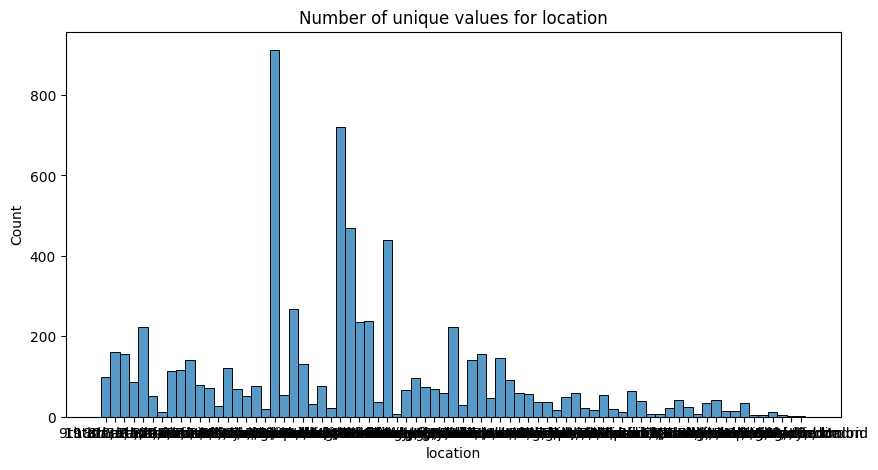

```
col: location     min: 10th arr., Paris     max: Westminster Borough, London
```

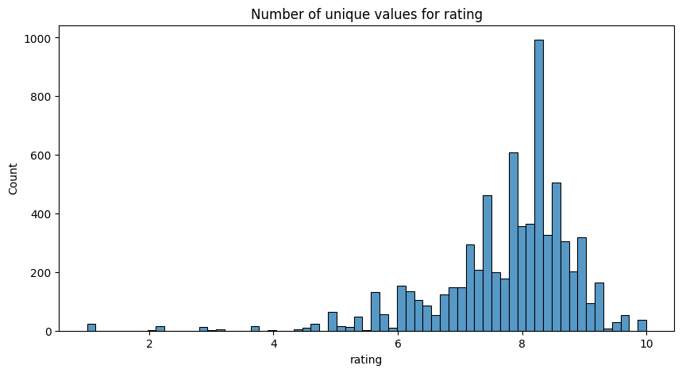

```
col: rating     min: 1.0     max: 10.0
```

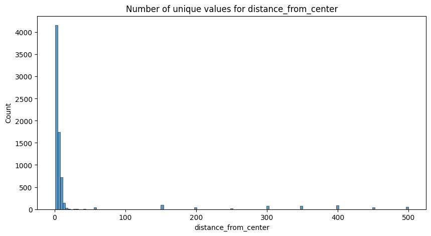

```
col: distance_from_center     min: 0.5     max: 500.0
```

```python
selected_columns = [1, 3, 8]

for col_index in selected_columns:
    col = hotels_df.columns[col_index]
    plt.figure(figsize=(10, 5))
    sns.histplot(hotels_df[col], bins=len(hotels_df[col].unique()))
    plt.title(f'Number of unique values for {col}')
    plt.show()
    print(f'col: {col}     min: {hotels_df[col].min()}     max: {hotels_df[col].max()}')
```

### 🔢 Manipulate Columns

In this subsection, we extract numerical values from columns.

```python
hotels_df['review'] = hotels_df['review'].str.replace(r'[^\d]', '', regex=True).astype(float)
# print(hotels_df['review'].head())
hotels_df['size'] = hotels_df['size'].str.extract(r'(\d+)').astype(float)
# print(hotels_df['size'].head())
hotels_df['price'] = hotels_df['price'].str.replace(r'[^\d]', '', regex=True).astype(float)
# print(hotels_df['price'].head())
hotels_df['nights'] = hotels_df['nights'].str.extract(r'(\d+)').astype(float)
# print(hotels_df['nights'].head())
hotels_df['adults'] = hotels_df['adults'].str.extract(r'(\d+)').astype(float)
# print(hotels_df['adults'].head())
```

### ➕ Additional Columns

In this subsection, we add some additional columns to the dataframe.

#### Splitting the location Feature into Area and City

```python
location_split = hotels_df['location'].str.split(',', n=1, expand=True)
hotels_df['area'] = location_split[0].str.strip()
hotels_df['city'] = location_split[1].str.strip()

hotels_df.drop(columns=['location'], inplace=True)
```

#### Calculating Price per Night per Adult

To standardize the price in the dataset, we calculate the price per night per adult using the following steps:

1. **Extract Price**: Ensure the `price` column contains only the numeric part.
2. **Extract Nights**: Ensure the `nights` column contains only numeric values.
3. **Extract Adults**: Ensure the `adults` column contains only numeric values.
4. **Calculate Standardized Price**: Use the formula:

   $\text{Price per night per adult} = \frac{\text{price}}{\text{nights} \times \text{adults}}$
5. **Replace the Original Price Column**: Update the `price` column with this calculated value to standardize it across all records.
6. **Drop Unnecessary Columns**: Remove the `nights` and `adults` columns if they are no longer needed for the analysis.

```python
hotels_df['price'] = hotels_df['price'].replace(',', '', regex=True).astype(float)
hotels_df['nights'] = hotels_df['nights'].astype(int)
hotels_df['adults'] = hotels_df['adults'].astype(int)

hotels_df['price'] = hotels_df['price'] / (hotels_df['nights'] * hotels_df['adults'])

hotels_df.drop(columns=['nights', 'adults'], inplace=True)

hotels_df['price'] = hotels_df['price'].replace([np.inf, -np.inf], np.nan)
```

### 🏷️ Assigning Labels

In this subsection, we want to assign labels to hotels 🏨, according to their price 💰.  
We have two labels:

- **0** for hotels with a price less than a threshold 🟢.
- **1** for those with higher prices 🔴.

To determine the threshold, we use the median of prices 📊.

```python
threshold = hotels_df['price'].median()
hotels_df['price'] = (hotels_df['price'] > threshold).astype(float)
```

### 🛠 Handling Missing Values 💡

There are several ways to handle missing numerical values in a dataset, some of which include:

- `Deleting rows with missing values` : This approach simply removes any rows that contain missing values, but it can be problematic if a large portion of the dataset contains missing values.
- `Imputing with mean or median` : This method involves replacing the missing values with the mean or median of the existing values in that column. This approach can work well if the distribution of the data is normal, but it may not be suitable for skewed data.
- `Imputing with regression` : This method involves using a regression model to predict the missing values based on other variables in the dataset. This approach can work well if there is a strong correlation between the missing value and other variables in the dataset.
- `Using a clustering algorithm` : This method involves using clustering algorithms to group similar data points together and then imputing the missing values with the mean or median value of the cluster. This approach can work well if there is a clear clustering structure in the data.
- `Using the K-Nearest Neighbors algorithm`: This method involves finding the K nearest neighbors of the missing value and imputing the missing value with the average of the K nearest neighbors. This approach can work well if there is a strong correlation between the missing value and its nearest neighbors.

The choice of method depends on the nature of the missing data and the analysis goals.

#### replace the values in the `free_cancellation` column

```python
# Replace 'Free cancellation' with 1 and NaN with 0
hotels_df['free_cancellation'] = hotels_df['free_cancellation'].apply(lambda x: 1 if x == 'Free cancellation' else 0)
hotels_df['free_cancellation'] = hotels_df['free_cancellation'].astype(float)
```

```python
print(f"Unique values in '{"free_cancellation"}':\n", hotels_df["free_cancellation"].unique(), "\n")
```

```
Unique values in 'free_cancellation':
 [0. 1.]
```

#### Detect Missing Values

```python
print(hotels_df.isnull().sum())
print(hotels_df.isnull().any())
```

```
name                       0
price                      0
rating                   193
quality                  153
review                   153
bed                       23
size                    4868
distance_from_center       0
room_type                  0
free_cancellation          0
area                       0
city                     155
dtype: int64
name                    False
price                   False
rating                   True
quality                  True
review                   True
bed                      True
size                     True
distance_from_center    False
room_type               False
free_cancellation       False
area                    False
city                     True
dtype: bool
```

#### virtualization of Missing Values

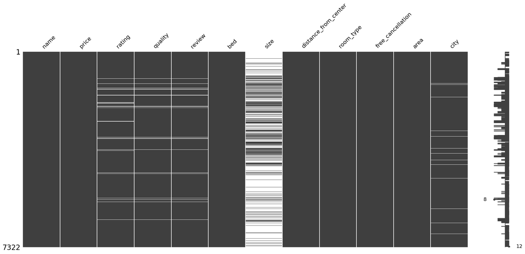

```python
msno.matrix(hotels_df)
plt.show()
```

#### Remove the `size` column from the DataFrame

```python
hotels_df = hotels_df.drop('size', axis=1)
```

#### Filling Missing Values for the `rating` Feature

**Recommended Approach:**

- Use the median rating specific to each restaurant for imputation. If a restaurant has no available ratings, fall back to the overall median.

**Rationale:**

- The restaurant-specific median offers a more precise estimate, reflecting the typical rating for that restaurant.
- The overall median acts as a reliable fallback, ensuring no data is left untreated.
- This strategy effectively handles missing values while maintaining robustness against outliers, preserving the integrity of the data.

```python
median_rating_per_restaurant = hotels_df.groupby('name')['rating'].transform('median')

hotels_df['rating'] = hotels_df['rating'].fillna(median_rating_per_restaurant)

# if any NaN values remain we replace it with the overall median
overall_median_rating = hotels_df['rating'].median()
hotels_df['rating'] = hotels_df['rating'].fillna(overall_median_rating)
```

#### Filling Missing Values for the `quality` Feature

**Recommended Approach:**

```python
hotels_df['quality'] = hotels_df.groupby('name')['quality'].transform(
    lambda x: x.fillna(x.mode()[0]) if not x.mode().empty else hotels_df['quality'].mode()[0]
)
```

#### Filling Missing Values for the `review` Feature

**Recommended Approach:**

- Replace missing values in the `review` feature with the median number of reviews for the same hotel (`name`).

**Rationale:**

- Using the median reflects the central tendency of reviews for each hotel, assuming consistency among its review counts.
- This approach maintains data integrity while reducing the impact of outliers.
- It ensures the dataset remains complete and reliable for further analysis.

```python
global_median = hotels_df['review'].median()

def fill_with_group_median(group):
    if group.isna().all():  # if the entire group is NaN
        return group.fillna(global_median)
    return group.fillna(group.median())

hotels_df['review'] = hotels_df.groupby('name')['review'].transform(fill_with_group_median)
```

#### Filling Missing Values for the `bed` Feature

**Recommended Approach:**

- Fill missing values in the `bed` feature using the mode (most frequent value) within each group of hotels, grouped by their `name`.

**Rationale:**

- The mode represents the most common value for each group, making it a reliable fill for missing data within each hotel.
- If a group has no mode (e.g., all values are NaN or unique), no replacement will occur, avoiding inappropriate imputation.
- This approach ensures that missing values are handled in a way that reflects the typical value for each hotel, maintaining consistency in the dataset.

```python
def fill_with_group_mode(group):
    if group.mode().empty:
        return #if mode cannot be calculated
    return group.fillna(group.mode()[0])

hotels_df['bed'] = hotels_df.groupby('name')['bed'].transform(fill_with_group_mode)
```

#### Filling Missing Values for the `city` Feature

**Recommended Approach:**

- Fill missing values in the `city` feature by using the city of the same restaurant (if available) or the city of a neighboring restaurant.

**Rationale:**

```python
def fill_city_with_name_or_neighbor(df):
    for i in range(len(df)):
        if pd.isna(df.loc[i, 'city']):
            if df['name'].iloc[:i].eq(df.loc[i, 'name']).any():
                df.loc[i, 'city'] = df.loc[i - 1, 'city']
            elif df['name'].iloc[i + 1:].eq(df.loc[i, 'name']).any():
                df.loc[i, 'city'] = df.loc[i + 1, 'city']
            #check neighbors
            elif i > 0 and pd.notna(df.loc[i - 1, 'city']):
                df.loc[i, 'city'] = df.loc[i - 1, 'city']  # Use previous row city
            elif i < len(df) - 1 and pd.notna(df.loc[i + 1, 'city']):
                df.loc[i, 'city'] = df.loc[i + 1, 'city']  # Use next row city

    return df

hotels_df = fill_city_with_name_or_neighbor(hotels_df)
```

#### Remove all remaining rows with any missing values

```python
hotels_df = hotels_df.dropna()
hotels_df.isna().sum()
```

```
name                    0
price                   0
rating                  0
quality                 0
review                  0
bed                     0
distance_from_center    0
room_type               0
free_cancellation       0
area                    0
city                    0
dtype: int64
```

### 🧮 Convert Categorical Feature to Numerical

In this subsection, we convert categorical features into numerical values using techniques like encoding, enabling the data to be used effectively for machine learning models.

```python
unique_qualities = hotels_df['quality'].unique()
quality_mapping = {quality: idx for idx, quality in enumerate(unique_qualities, start=1)}
hotels_df['quality'] = hotels_df['quality'].map(quality_mapping)
print("Mapping:", quality_mapping)
```

```
Mapping: {'Good': 1, 'Very good': 2, 'Fabulous': 3, 'Superb': 4, 'Review score': 5, 'Exceptional': 6, 'Good 7.3': 7, 'Superb 9.0': 8, 'Fabulous 8.9': 9, 'Fabulous 8.7': 10, 'Exceptional 9.6': 11, 'Review score 6.4': 12, 'Very good 8.1': 13}
```

```python
unique_bed = hotels_df['bed'].unique()
bed_mapping = {bed: idx for idx, bed in enumerate(unique_bed, start=1)}
hotels_df['bed'] = hotels_df['bed'].map(bed_mapping)
print("Mapping:", bed_mapping)
```

```
Mapping: {'1 double bed': 1, '1 single bed': 2, '1 large double bed': 3, 'Multiple bed types': 4, '1 bunk bed': 5, '1 extra-large double bed': 6, 'Beds: 1 double or 2 singles': 7, '2 single beds': 8, '4 bunk beds': 9, '2 double beds': 10, '2 beds (1 double, 1 sofa bed)': 11, '2 beds (1 double, 1 bun…
```

```python
unique_room_type = hotels_df['room_type'].unique()
room_type_mapping = {room_type: idx for idx, room_type in enumerate(unique_room_type, start=1)}
hotels_df['room_type'] = hotels_df['room_type'].map(room_type_mapping)
print("Mapping:", room_type_mapping)
```

```
Mapping: {'Suite': 1, 'Single Bed in 6-Bed Dormitory Room': 2, 'Comfort Single Room': 3, 'Classic Room': 4, 'Comfort Double Room': 5, 'Single Room': 6, 'Standard Single Room': 7, 'Executive Double Room': 8, 'Large Triple Room': 9, 'Standard Double Room': 10, 'Bed in 10-Bed Mixed Dormitory Room': 11,…
```

```python
unique_city = hotels_df['city'].unique()
city_mapping = {city: idx for idx, city in enumerate(unique_city, start=1)}
hotels_df['city'] = hotels_df['city'].map(city_mapping)
print("Mapping:", city_mapping)
```

```
Mapping: {'Paris': 1, 'Madrid': 2, 'Berlin': 3, 'London': 4}
```

```python
unique_area = hotels_df['area'].unique()
area_mapping = {area: idx for idx, area in enumerate(unique_area, start=1)}
hotels_df['area'] = hotels_df['area'].map(area_mapping)
print("Mapping:", area_mapping)
```

```
Mapping: {'9th arr.': 1, '19th arr.': 2, '18th arr.': 3, '8th arr.': 4, '12th arr.': 5, '3rd arr.': 6, '7th arr.': 7, '15th arr.': 8, '10th arr.': 9, '20th arr.': 10, '16th arr.': 11, '13th arr.': 12, '5th arr.': 13, '17th arr.': 14, '14th arr.': 15, '4th arr.': 16, 'Barajas': 17, 'Villaverde': 18, …
```

```python
unique_name = hotels_df['name'].unique()
name_mapping = {name: idx for idx, name in enumerate(unique_name, start=1)}
hotels_df['name'] = hotels_df['name'].map(name_mapping)
print("Mapping:", name_mapping)
```

```
Mapping: {'WIT Hotel': 1, 'UCPA SPORT STATION HOSTEL PARIS': 2, 'Timhotel Montmartre': 3, 'Hôtel Galileo Champs Elysées': 4, 'Hôtel Le Daum': 5, 'Le Relais du Marais': 6, 'Grand Hotel Dore': 7, 'Hôtel de Lille - Saint-Germain des Près': 8, 'Hôtel Moderniste': 9, "Le Robinet d'Or": 10, 'Generator Par…
```

```python
print(hotels_df.select_dtypes(include=['number']).columns)
print(hotels_df.select_dtypes(include=['object']).columns)
```

```
Index(['name', 'price', 'rating', 'quality', 'review', 'bed',
       'distance_from_center', 'room_type', 'free_cancellation', 'area',
       'city'],
      dtype='object')
Index([], dtype='object')
```

### 🗃️ Homogenization and saving cleaned dataset

In this subsection, we standardize the data by formatting issues, then save the cleaned dataset for further analysis or modeling.

```python
for column in hotels_df.columns:
    if pd.api.types.is_numeric_dtype(hotels_df[column]):
        hotels_df[column] = hotels_df[column].astype(float)
```

```python
display(hotels_df.info())
```

```
<class 'pandas.core.frame.DataFrame'>
Index: 7312 entries, 0 to 7321
Data columns (total 11 columns):
 #   Column                Non-Null Count  Dtype
---  ------                --------------  -----
 0   name                  7312 non-null   float64
 1   price                 7312 non-null   float64
 2   rating                7312 non-null   float64
 3   quality               7312 non-null   float64
 4   review                7312 non-null   float64
 5   bed                   7312 non-null   float64
 6   distance_from_center  7312 non-null   float64
 7   room_type             7312 non-null   float64
 8   free_cancellation     7312 non-null   float64
 9   area                  7312 non-null   float64
 10  city                  7312 non-null   float64
dtypes: float64(11)
memory usage: 685.5 KB
```

```
None
```

```python
hotels_df.to_csv("hotels_data_cleaned.csv", index=False)
```

## 📊 Data Visualization

In this section, we create visual representations of the data to identify patterns, trends, and insights for better understanding and analysis🎯.

### Correlation Heatmap

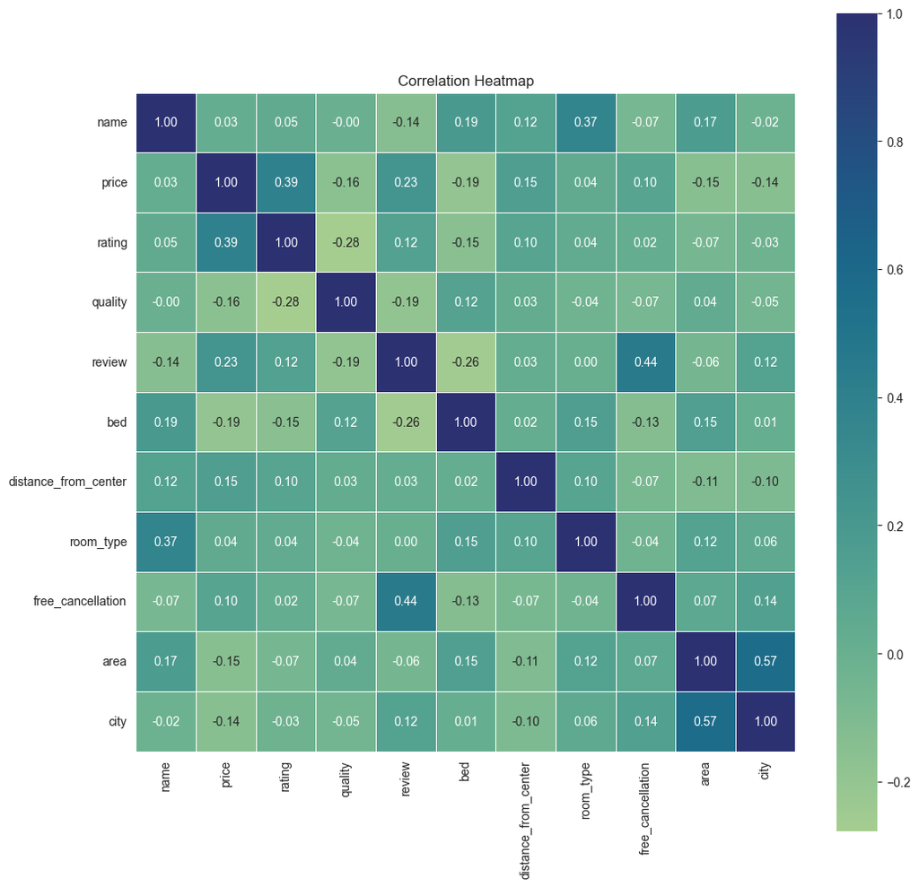

```python
correlation_matrix = hotels_df.corr(method='pearson', numeric_only=True)

sns.set_style('whitegrid')
color_map = sns.color_palette("crest", as_cmap=True)
plt.figure(figsize=(12, 12))
sns.heatmap(
    correlation_matrix,
    annot=True,
    fmt='.2f',
    linewidths=0.5,
    cbar=True,
    cmap=color_map,
    square=True
)
plt.title("Correlation Heatmap")
plt.show()
```

### Visualizing Correlation Between Features and Target

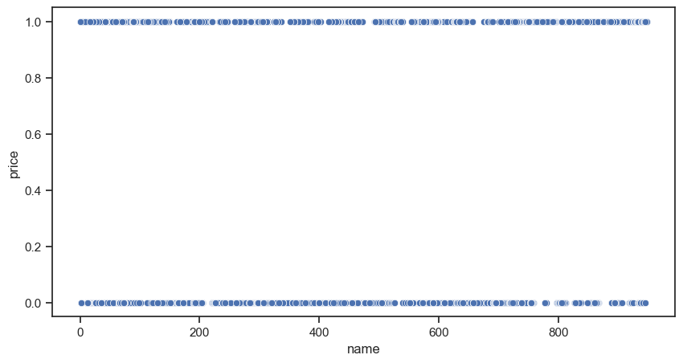

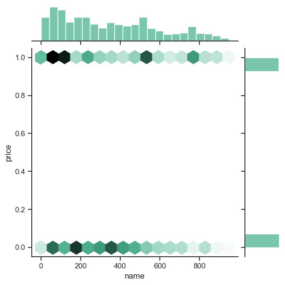

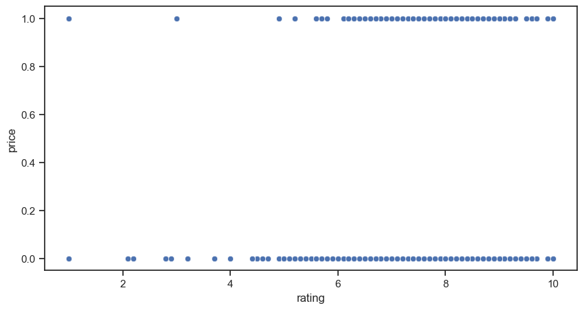

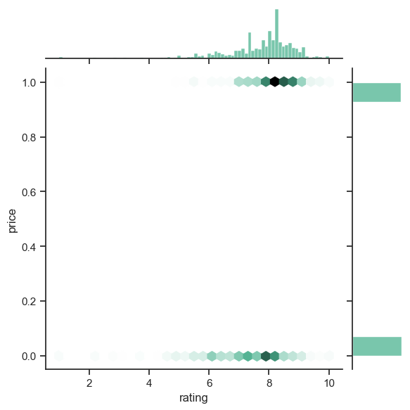

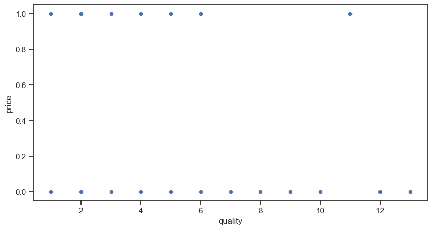

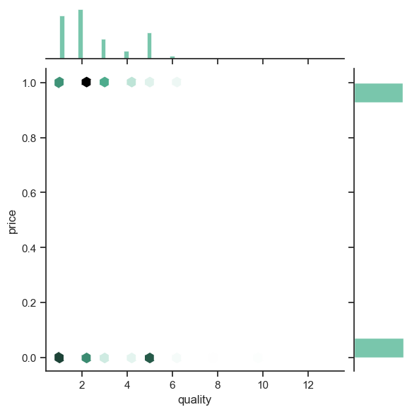

```python
selected_features_count = 4

sns.set_theme(style="ticks")

plt.figure(figsize=(10, 5))
sns.scatterplot(x="name", y='price', data=hotels_df)
sns.jointplot(x="name", y='price', data=hotels_df, kind='hex', color="#4CB391")
plt.show()

for col in hotels_df.columns[2:selected_features_count]:
    plt.figure(figsize=(10, 5))
    sns.scatterplot(x=col, y='price', data=hotels_df)
    sns.jointplot(x=col, y='price', data=hotels_df, kind='hex', color="#4CB391")
    plt.show()
```

## 🏷️ Classification

In this section, we will go through the classification pipeline. We will deploy several machine learning models to classify hotels based on their price 💵. Finally, we will implement a boosting algorithm from scratch 🛠 and compare its performance with the library implementation 📚.

### 🔀 Train-Test Split

we divide the data into a training set and a test set. Use 20% of the data for testing and 80% for training 📊.

```python
SPLIT_RATIO = 0.2
RANDOM_STATE = 18

X = hotels_df.drop('price', axis=1)
y = hotels_df['price']

X_train, X_test, y_train, y_test = train_test_split(X, y, test_size=SPLIT_RATIO, random_state=RANDOM_STATE)
```

### 🌐 Normalizing Numerical Features in the Dataset

**Approach:**

- We normalize the `rating`, `review`, and `distance_from_center` features to ensure they are on the same scale, which is important for many machine learning algorithms ⚙️.

**Methods Used:**

1. **Min-Max Scaling:**
   - Scales features to a range between [0, 1]. This is useful when you need to preserve the relationships between the original data points within a fixed range.
   - Applied using `MinMaxScaler()` from `sklearn`.
2. **Standardization (commented out):**
   - Scales features to have a mean of 0 and a standard deviation of 1. This is useful when working with algorithms that assume normally distributed data or when managing outliers.
   - Applied using `StandardScaler()` from `sklearn`.

**Reason for Normalization:**

- Normalizing the features ensures that no single feature dominates others due to differences in scale. Many machine learning algorithms, such as KNN or SVM, rely on distance metrics, and features with larger ranges could disproportionately influence the model. Normalization helps to achieve fair treatment of each feature, improving model performance.

```python
numerical_columns = ['rating', 'review', 'distance_from_center']

scaler = MinMaxScaler()
hotels_df[numerical_columns] = scaler.fit_transform(hotels_df[numerical_columns])

# scaler = StandardScaler()
# hotels_df[numerical_columns] = scaler.fit_transform(hotels_df[numerical_columns])

hotels_df[numerical_columns].head()
```

|  | rating | review | distance_from_center |
| --- | --- | --- | --- |
| 0 | 0.677778 | 0.131309 | 0.002803 |
| 1 | 0.777778 | 0.235631 | 0.008208 |
| 2 | 0.811111 | 0.100740 | 0.005806 |
| 3 | 0.844444 | 0.057953 | 0.007407 |
| 4 | 0.811111 | 0.050629 | 0.007207 |

## 🚀 Deploying Sklearn Models

In this section, we use built-in models from the sklearn library for the classification task. And show the complete classification report, including the confusion matrix, precision, recall, F1-score, and accuracy 📊.

### 🧪 Analyzing Model Performance

1. **Confusion Matrix** :

   Displays the true positive, false positive, true negative, and false negative counts for each class.
2. **Accuracy** :

   The ratio of correctly predicted samples to the total samples.
3. **Precision, Recall, and F1-Score** :
   - Calculated for each class and averages.
   - `Precision`: $\frac{\text{True Positives}}{\text{True Positives } + \text{ False Positives}}$
   - `Recall`: $\frac{\text{True Positives}}{\text{True Positives} + \text{ False Negatives}}$
   - `F1-Score`: Harmonic mean of precision and recall.
4. **Averaging Methods** :
   - **Micro** : Aggregates contributions from all classes, treating every instance equally.
   - **Macro** : Calculates metrics independently for each class and then takes the mean, treating all classes equally.
   - **Weighted** : Accounts for the imbalance in class distribution by weighting metrics by class frequency.

```python
def evaluate_model(model_name, model, y_test):

    y_pred = model.predict(X_test)

    plt.figure(figsize=(5, 5))
    sns.heatmap(confusion_matrix(y_test, y_pred), annot=True, fmt='d', cmap='Blues', cbar=False)
    plt.title(f'{model_name} Confusion Matrix')
    plt.ylabel('Actual')
    plt.xlabel('Predicted')
    plt.show()

    accuracy = accuracy_score(y_test, y_pred)
    print(f"\nAccuracy: {accuracy:.4f}")

    precision = precision_score(y_test, y_pred, average=None)
    recall = recall_score(y_test, y_pred, average=None)
    f1 = f1_score(y_test, y_pred, average=None)

    print("\nPrecision per class:", precision)
    print("\nRecall per class:", recall)
    print("\nF1-Score per class:", f1)

    weighted_precision = precision_score(y_test, y_pred, average='weighted')
    weighted_recall = recall_score(y_test, y_pred, average='weighted')
    weighted_f1 = f1_score(y_test, y_pred, average='weighted')

    micro_precision = precision_score(y_test, y_pred, average='micro')
    micro_recall = recall_score(y_test, y_pred, average='micro')
    micro_f1 = f1_score(y_test, y_pred, average='micro')

    macro_precision = precision_score(y_test, y_pred, average='macro')
    macro_recall = recall_score(y_test, y_pred, average='macro')
    macro_f1 = f1_score(y_test, y_pred, average='macro')

    print("\nWeighted Averages:")
    print(f"Precision: {weighted_precision:.4f}, Recall: {weighted_recall:.4f}, F1-Score: {weighted_f1:.4f}")

    print("\nMicro Averages:")
    print(f"Precision: {micro_precision:.4f}, Recall: {micro_recall:.4f}, F1-Score: {micro_f1:.4f}")

    print("\nMacro Averages:")
    print(f"Precision: {macro_precision:.4f}, Recall: {macro_recall:.4f}, F1-Score: {macro_f1:.4f}")
```

### 📉 Gaussian Naive Bayes

#### ⚒️ Gaussian Naive Bayes implementation

```python
nb_model = GaussianNB()
nb_model.fit(X_train, y_train)
```

```
GaussianNB()
```

#### 🔎 Analyzing Gaussian Naive Bayes Model Performance

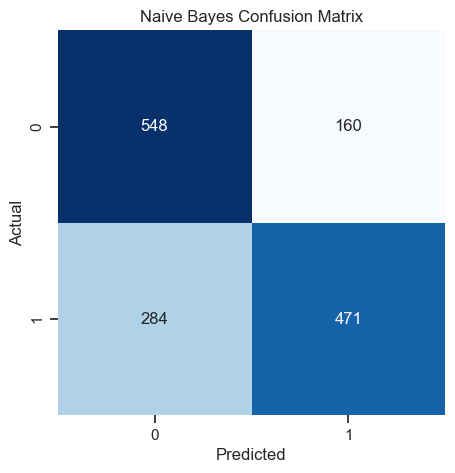

```
Accuracy: 0.6965

Precision per class: [0.65865385 0.74643423]

Recall per class: [0.7740113  0.62384106]

F1-Score per class: [0.71168831 0.67965368]

Weighted Averages:
Precision: 0.7040, Recall: 0.6965, F1-Score: 0.6952

Micro Averages:
Precision: 0.6965, Recall: 0.6965, F1-Score: 0.6965

Macro Averages:
Precision: 0.7025, Recall: 0.6989, F1-Score: 0.6957
```

```python
evaluate_model("Naive Bayes", nb_model, y_test)
```

### 🌳 Decision Tree Classifier

#### ⚒️ Decision Tree Classifier Implementation

1. **Pruning with Hyperparameters**:
   - **`max_depth`**: Limits tree depth to prevent overfitting.
   - **`min_samples_split`**: Minimum samples required to split a node.
   - **`min_samples_leaf`**: Minimum samples in a leaf node.
   - **`ccp_alpha`**: Controls cost-complexity pruning, balancing tree complexity and accuracy.
2. **Hyperparameter Optimization**:
   - **`GridSearchCV`**: Exhaustively searches for the best hyperparameter combination.
   - **`cv=5`**: 5-fold cross-validation for more reliable evaluation.
3. **Code Implementation**:
   - Hyperparameters are defined in `param_grid`.
   - **`GridSearchCV`** is used to find optimal parameters, with the best ones retrieved via `grid_search.best_params_`.

```python
param_grid = {
    'criterion': ['gini', 'entropy'],
    'max_depth': [None, 5, 10, 20],
    'min_samples_split': [2, 5, 10],
    'min_samples_leaf': [1, 2, 5],
    'ccp_alpha': [0.0, 0.01, 0.1]
}

dt_model = DecisionTreeClassifier(random_state=42)

grid_search = GridSearchCV(estimator=dt_model, param_grid=param_grid, cv=5, scoring='accuracy', n_jobs=-1)

grid_search.fit(X_train, y_train)

best_model = grid_search.best_estimator_
print("Best Hyperparameters:", grid_search.best_params_)
```

```
Best Hyperparameters: {'ccp_alpha': 0.0, 'criterion': 'entropy', 'max_depth': None, 'min_samples_leaf': 1, 'min_samples_split': 2}
```

#### 🔎 Analyzing Decision Tree Classifier Model Performance

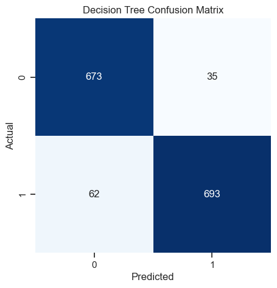

```
Accuracy: 0.9337

Precision per class: [0.91564626 0.95192308]

Recall per class: [0.95056497 0.91788079]

F1-Score per class: [0.93277893 0.93459204]

Weighted Averages:
Precision: 0.9344, Recall: 0.9337, F1-Score: 0.9337

Micro Averages:
Precision: 0.9337, Recall: 0.9337, F1-Score: 0.9337

Macro Averages:
Precision: 0.9338, Recall: 0.9342, F1-Score: 0.9337
```

```python
evaluate_model("Decision Tree", best_model, y_test)
```

#### 👀 Decision Tree Classifier virtualization

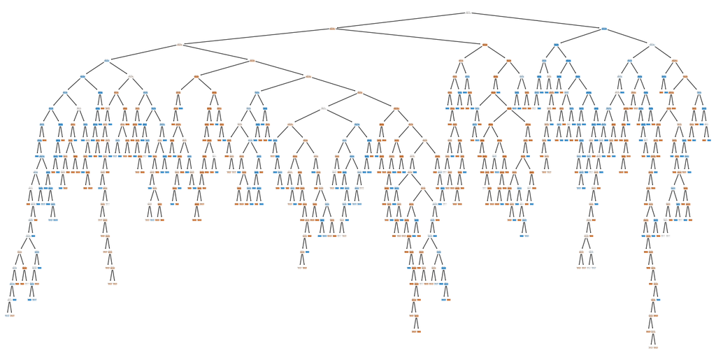

```python
plt.figure(figsize=(20, 10))
plot_tree(best_model, filled=True)
plt.show()
```

### 🌲🌳 Random Forest Classifier

#### ⚒️ Random Forest Classifier Implementation

1. **Model Setup**:
   - **`RandomForestClassifier`**: Combines decision trees for better accuracy and robustness.
   - **`random_state=42`**: Ensures reproducibility.
2. **Hyperparameter Tuning with RandomizedSearchCV**:
   - **`RandomizedSearchCV`**: Efficiently samples a subset of hyperparameter combinations.
   - **`param_dist`**: Defines hyperparameters like `n_estimators`, `max_depth`, `min_samples_split`, etc.
   - **`n_iter=100`, `cv=5`, `n_jobs=-1`, `random_state=42`**: Samples 100 combinations with 5-fold cross-validation and parallel computation.
3. **Best Hyperparameters**:
   - **`random_search.best_params_`**: Retrieves the best hyperparameter combination.
4. **Model Evaluation**:
   - **`random_search.best_estimator_`**: Extracts the best model for predictions and evaluates accuracy on the test set.
5. **Benefits of RandomizedSearchCV**:
   - More efficient than `GridSearchCV`, especially for large hyperparameter spaces.
   - Balances cost and search comprehensiveness, quickly identifying a strong baseline model.

```python
rf_model = RandomForestClassifier(random_state=42)

param_dist = {
    'n_estimators': [100, 200, 300, 500, 1000],
    'max_depth': [None, 10, 20, 30, 40, 50],
    'min_samples_split': [2, 5, 10, 20],
    'min_samples_leaf': [1, 2, 4, 6, 10],
    'max_features': ['sqrt', 'log2', None],
    'bootstrap': [True, False]
}

random_search = RandomizedSearchCV(estimator=rf_model, param_distributions=param_dist,
                                   n_iter=100, cv=5, n_jobs=-1, verbose=2, random_state=42)

random_search.fit(X_train, y_train)

print("Best Hyperparameters:", random_search.best_params_)
```

```
Fitting 5 folds for each of 100 candidates, totalling 500 fits
Best Hyperparameters: {'n_estimators': 300, 'min_samples_split': 5, 'min_samples_leaf': 1, 'max_features': 'sqrt', 'max_depth': 30, 'bootstrap': False}
```

#### 🔎 Analyzing Random Forest Classifier Model Performance

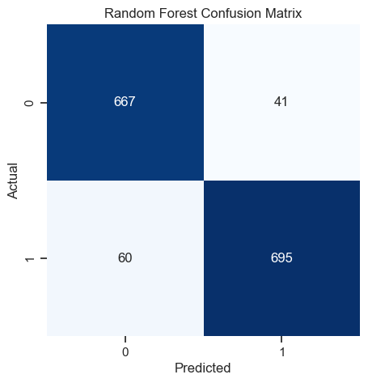

```
Accuracy: 0.9310

Precision per class: [0.91746905 0.94429348]

Recall per class: [0.9420904 0.9205298]

F1-Score per class: [0.92961672 0.93226023]

Weighted Averages:
Precision: 0.9313, Recall: 0.9310, F1-Score: 0.9310

Micro Averages:
Precision: 0.9310, Recall: 0.9310, F1-Score: 0.9310

Macro Averages:
Precision: 0.9309, Recall: 0.9313, F1-Score: 0.9309
```

```python
evaluate_model("Random Forest", random_search, y_test)
```

### ⚡️ Adaptive Boosting

#### ⚒️ Adaptive Boosting implementation

```python
ada_model = AdaBoostClassifier(random_state=42)

param_dist = {
    'n_estimators': [50, 100, 150, 200, 250],
    'learning_rate': [0.01, 0.1, 0.5, 1, 1.5],
    'algorithm': ['SAMME']
}

random_search = RandomizedSearchCV(estimator=ada_model, param_distributions=param_dist,
                                   n_iter=25, cv=5, n_jobs=-1, verbose=2, random_state=42)

random_search.fit(X_train, y_train)

print("Best Hyperparameters:", random_search.best_params_)
```

```
Fitting 5 folds for each of 25 candidates, totalling 125 fits
Best Hyperparameters: {'n_estimators': 250, 'learning_rate': 1.5, 'algorithm': 'SAMME'}
```

#### 🔎 Analyzing Adaptive Boosting Model Performance

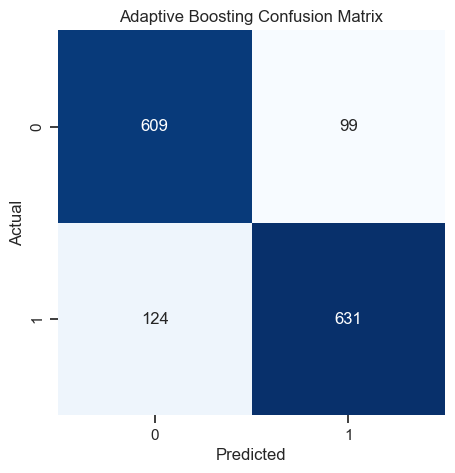

```
Accuracy: 0.8476

Precision per class: [0.8308322  0.86438356]

Recall per class: [0.86016949 0.83576159]

F1-Score per class: [0.84524636 0.84983165]

Weighted Averages:
Precision: 0.8481, Recall: 0.8476, F1-Score: 0.8476

Micro Averages:
Precision: 0.8476, Recall: 0.8476, F1-Score: 0.8476

Macro Averages:
Precision: 0.8476, Recall: 0.8480, F1-Score: 0.8475
```

```python
evaluate_model("Adaptive Boosting", random_search, y_test)
```

#### 📊 Analyzing Adaptive Boosting Model with difference n_estimators

1. **Effect of `n_estimators`** :
   - A loop is used to evaluate the effect of varying `n_estimators` on model performance.
   - Models are trained with different values of `n_estimators`, and their accuracy scores on the test set are recorded.
   - Results are visualized using a line plot to observe the trend in accuracy.
2. **Plot Insights** :
   - The plot shows how the accuracy changes with the number of estimators (`n_estimators`).
   - Helps determine the optimal value of `n_estimators` for balancing performance and computation cost.

```
n_estimators = 50: Accuracy = 0.7949
```

```
n_estimators = 100: Accuracy = 0.8182
```

```
n_estimators = 200: Accuracy = 0.8462
```

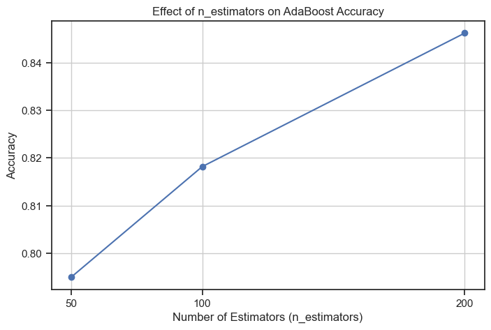

```python
n_estimators_values = [50, 100, 200]
accuracies = []
for n_estimators in n_estimators_values:

    ada_model = AdaBoostClassifier(n_estimators=n_estimators, random_state=42)

    ada_model.fit(X_train, y_train)

    y_pred = ada_model.predict(X_test)

    accuracy = accuracy_score(y_test, y_pred)
    accuracies.append(accuracy)
    print(f"n_estimators = {n_estimators}: Accuracy = {accuracy:.4f}")

plt.figure(figsize=(8, 5))
plt.plot(n_estimators_values, accuracies, marker='o', linestyle='-', color='b')
plt.title("Effect of n_estimators on AdaBoost Accuracy")
plt.xlabel("Number of Estimators (n_estimators)")
plt.ylabel("Accuracy")
plt.grid(True)
plt.xticks(n_estimators_values)
plt.show()
```

### ⚡️ XGBoost

#### ⚒️ XGBoost Implementation

```python
xgb_model = xgb.XGBClassifier(eval_metric='logloss', random_state=42)

param_grid = {
    'learning_rate': [0.01, 0.1, 0.2],
    'n_estimators': [50, 100, 150],
    'min_child_weight': [1, 3, 5],
    'max_depth': [3, 5, 7],
    'subsample': [0.8, 1.0],
    'colsample_bytree': [0.8, 1.0]
}

grid_search = GridSearchCV(
    estimator=xgb_model,
    param_grid=param_grid,
    scoring='accuracy',
    cv=5,
    verbose=1,
    n_jobs=-1
)

grid_search.fit(X_train, y_train)

best_params = grid_search.best_params_
best_score = grid_search.best_score_

best_model = grid_search.best_estimator_
y_pred = best_model.predict(X_test)
accuracy = accuracy_score(y_test, y_pred)

print("Best Parameters:", best_params)
```

```
Fitting 5 folds for each of 324 candidates, totalling 1620 fits
Best Parameters: {'colsample_bytree': 0.8, 'learning_rate': 0.2, 'max_depth': 7, 'min_child_weight': 1, 'n_estimators': 100, 'subsample': 0.8}
```

#### 🔎 Analyzing XGBoost Model Performance

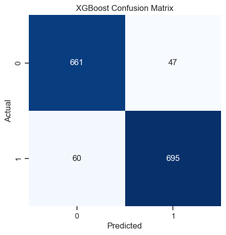

[output not shown]

```python
evaluate_model("XGBoost", best_model, y_test)
```

## 🛠 From Scratch

In this section, we implement the SAMME algorithm for adaptive boosting from scratch.Then we deploy this boosting model and a base estimator, which is Gaussian Naive Bayes here, to classify hotels.

### ⚒️ SAMME algorithm implementation

```python
class SimpleMultiClassBoosting(BaseEstimator, ClassifierMixin):
    def __init__(self, base_estimator=GaussianNB, n_estimators=50):
        self.base_estimator = base_estimator if base_estimator is not None else GaussianNB()
        self.n_estimators = n_estimators
        self.learners = []
        self.learner_weights = []

    def fit(self, X, y):
        n_samples, n_classes = X.shape[0], len(np.unique(y))
        self.weights = (1/n_samples) * np.ones(n_samples, dtype=float) # initialize weights uniformly
        for _ in range(self.n_estimators):
            learner = GaussianNB() # instanciate model
            learner.fit(X, y, sample_weight=self.weights) # fit to samples, using weights
            pred = learner.predict(X) # predict the batch
            missClassified = pred != y # get index of misclassified samples

            # TODO : compute learner error rate according to SAMME algorithm
            error_rate = np.sum(self.weights[missClassified])

            # TODO : compute learner weight using SAMME algorithm
            learner_weight = np.log((1 - error_rate) / error_rate) + np.log(n_classes - 1)

            # TODO : a classifier with error rate which is worse than random should be dropped
            # hint : error rate of untrained classifier : 1 - (1 / n_classes)
            if error_rate >= 1 - (1 / n_classes):
                break

            # TODO : increase the weights of misclassified samples according to SAMME algorithm
            self.weights[missClassified] *= np.exp(learner_weight)
            self.weights /= np.sum(self.weights)
            self.learners.append(learner)

            # TODO : store learner weight in self.learner_weights
            self.learner_weights.append(learner_weight)

    def predict(self, X):
        # note that X can contain multiple samples in shape of array, in which, each row corresponds to a query
        predictionsOfLearners = []
        for learner in self.learners:
            predictionsOfLearners.append(learner.predict(X)) # collect predictions from each learner

        # TODO : weighted vote for each sample's prediction across all learners, each learner's weight is stored in self.learner_weights
        predictionsOfLearners = np.array(predictionsOfLearners)
        unique_classes = np.unique(np.hstack([learner.predict(X) for learner in self.learners]))
        class_to_index = {cls: idx for idx, cls in enumerate(unique_classes)}

        n_samples = X.shape[0]
        n_classes = len(unique_classes)
        weighted_votes = np.zeros((n_samples, n_classes))

        for i, weight in enumerate(self.learner_weights):
            for j in range(n_samples):
                class_label = predictionsOfLearners[i, j]
                class_index = class_to_index[class_label] # Map label to index
                weighted_votes[j, class_index] += weight

        # TODO : make final prediction by considering the label which has highest weighted vote

        final_predictions_indices = np.argmax(weighted_votes, axis=1)
        final_prediction = np.array(unique_classes[final_predictions_indices])

        return final_prediction
```

### 🔎 Analyzing `SAMME` algorithm Model Performance

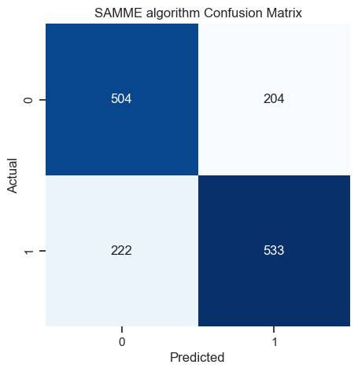

```
Accuracy: 0.7088

Precision per class: [0.69421488 0.72320217]

Recall per class: [0.71186441 0.70596026]

F1-Score per class: [0.70292887 0.71447721]

Weighted Averages:
Precision: 0.7092, Recall: 0.7088, F1-Score: 0.7089

Micro Averages:
Precision: 0.7088, Recall: 0.7088, F1-Score: 0.7088

Macro Averages:
Precision: 0.7087, Recall: 0.7089, F1-Score: 0.7087
```

```python
model = SimpleMultiClassBoosting()
model.fit(X_train, y_train)
evaluate_model("SAMME algorithm", model, y_test)
```

### 📊 Comparison with Library Implementation:

1. **Accuracy** :

   The Scikit-learn implementation performs significantly better than the manual implementation due to its optimized algorithms and efficient handling of edge cases. However, the scratch implementation provides valuable insights into the mechanics of Boosting, making it a useful learning tool.